# Lab 4: Childcare Costs in California

- Show All Code
- Hide All Code
- View Source

Author

Tillman Erb

## The Data

In this lab we’re going look at the median weekly cost of childcare in California. A detailed description of the data can be found [here](https://github.com/rfordatascience/tidytuesday/blob/master/data/2023/2023-05-09/readme.md).

The data come to us from [TidyTuesday](https://github.com/rfordatascience/tidytuesday).

**0. Load the appropriate libraries and the data.**

```r
library(tidyverse)
library(here)
```

```r
childcare_costs <- read_csv('https://raw.githubusercontent.com/rfordatascience/tidytuesday/master/data/2023/2023-05-09/childcare_costs.csv')

counties <- read_csv('https://raw.githubusercontent.com/rfordatascience/tidytuesday/master/data/2023/2023-05-09/counties.csv')
```

**1. Briefly describe the dataset (~ 4 sentences). What information does it contain?** The dataset contains information on childcare costs year over year for counties in the United States. The childcare_costs dataframe has 34567 rows and 61 columns, and the rows have unique values represented by county and year. childcare_costs (2008 - 2018) contains data from the national database of childcare prices on a variety of metrics such as unemployment rates, poverty rates, and childcare costs. The county is represented by the count_fips_code, allowing the information to be joined to the counties dataframe for additional information about each county, and has 3144 rows and 4 columns.

## California Childcare Costs

Let’s start by focusing only on California.

```r
ca_childcare <- counties |>
  filter(state_abbreviation == 'CA') |>
  inner_join(childcare_costs)

ca_childcare
```

```
# A tibble: 638 × 64
   county_fips_code county_name  state_name state_abbreviation study_year unr_16
              <dbl> <chr>        <chr>      <chr>                   <dbl>  <dbl>
 1             6001 Alameda Cou… California CA                       2008   6.6
 2             6001 Alameda Cou… California CA                       2009   7.71
 3             6001 Alameda Cou… California CA                       2010   8.5
 4             6001 Alameda Cou… California CA                       2011   9.21
 5             6001 Alameda Cou… California CA                       2012   9.91
 6             6001 Alameda Cou… California CA                       2013  10.3
 7             6001 Alameda Cou… California CA                       2014   9.6
 8             6001 Alameda Cou… California CA                       2015   8.26
 9             6001 Alameda Cou… California CA                       2016   7.11
10             6001 Alameda Cou… California CA                       2017   6.05
# ℹ 628 more rows
# ℹ 58 more variables: funr_16 <dbl>, munr_16 <dbl>, unr_20to64 <dbl>,
#   funr_20to64 <dbl>, munr_20to64 <dbl>, flfpr_20to64 <dbl>,
#   flfpr_20to64_under6 <dbl>, flfpr_20to64_6to17 <dbl>,
#   flfpr_20to64_under6_6to17 <dbl>, mlfpr_20to64 <dbl>, pr_f <dbl>,
#   pr_p <dbl>, mhi_2018 <dbl>, me_2018 <dbl>, fme_2018 <dbl>, mme_2018 <dbl>,
#   total_pop <dbl>, one_race <dbl>, one_race_w <dbl>, one_race_b <dbl>, …
```

**3. Using a function from the `forcats` package, complete the code below to create a new variable where each county is categorized into one of the [10 Census regions](https://census.ca.gov/regions/) in California. Use the Region description (from the plot), not the Region number.**  
*Hint: This is probably a good place to use ChatGPT to reduce on tedious work. But you do need to know how to prompt ChatGPT to make it useful!*

```r
#Used Gemini Advanced here to assist with collapsing the categories. See https://gemini.google.com/app/97fc26f14e181a41 for the conversation
ca_childcare <- ca_childcare |>
  mutate(county_name = str_remove(county_name, " County"),
        region = fct_collapse(county_name,
        "Superior California" = c("Butte", "El Dorado", "Colusa", "Glenn", "Lassen", "Modoc", "Nevada", "Placer", "Plumas", "Sacramento", "Shasta", "Sierra", "Siskiyou", "Sutter", "Tehama", "Yolo", "Yuba"),
        "North Coast" = c("Del Norte", "Humboldt", "Lake", "Mendocino", "Napa", "Sonoma", "Trinity"),
        "San Francisco Bay Area" = c("Alameda", "Contra Costa", "Marin", "San Francisco", "San Mateo", "Santa Clara", "Solano"),
        "Northern San Joaquin Valley" = c("Alpine", "Amador", "Calaveras", "Madera", "Mariposa", "Merced", "Mono", "San Joaquin", "Stanislaus", "Tuolumne"),
        "Central Coast" = c("Monterey", "San Benito", "San Luis Obispo", "Santa Barbara", "Santa Cruz", "Ventura"),
        "Southern San Joaquin Valley" = c("Fresno", "Inyo", "Kern", "Kings", "Tulare"),
        "Inland Empire" = c("Riverside", "San Bernardino"),
        "Los Angeles County" = "Los Angeles",
        "Orange County" = "Orange",
        "San Diego County" = c("Imperial", "San Diego")
        ), .before = state_abbreviation)

ca_childcare
```

```
# A tibble: 638 × 65
   county_fips_code county_name state_name region  state_abbreviation study_year
              <dbl> <chr>       <chr>      <fct>   <chr>                   <dbl>
 1             6001 Alameda     California San Fr… CA                       2008
 2             6001 Alameda     California San Fr… CA                       2009
 3             6001 Alameda     California San Fr… CA                       2010
 4             6001 Alameda     California San Fr… CA                       2011
 5             6001 Alameda     California San Fr… CA                       2012
 6             6001 Alameda     California San Fr… CA                       2013
 7             6001 Alameda     California San Fr… CA                       2014
 8             6001 Alameda     California San Fr… CA                       2015
 9             6001 Alameda     California San Fr… CA                       2016
10             6001 Alameda     California San Fr… CA                       2017
# ℹ 628 more rows
# ℹ 59 more variables: unr_16 <dbl>, funr_16 <dbl>, munr_16 <dbl>,
#   unr_20to64 <dbl>, funr_20to64 <dbl>, munr_20to64 <dbl>, flfpr_20to64 <dbl>,
#   flfpr_20to64_under6 <dbl>, flfpr_20to64_6to17 <dbl>,
#   flfpr_20to64_under6_6to17 <dbl>, mlfpr_20to64 <dbl>, pr_f <dbl>,
#   pr_p <dbl>, mhi_2018 <dbl>, me_2018 <dbl>, fme_2018 <dbl>, mme_2018 <dbl>,
#   total_pop <dbl>, one_race <dbl>, one_race_w <dbl>, one_race_b <dbl>, …
```

**4. Let’s consider the median household income of each region, and how that income has changed over time. Create a table with ten rows, one for each region, and two columns, one for 2008 and one for 2018. The cells should contain the `median` of the median household income (expressed in 2018 dollars) of the `region` and the `study_year`. Arrange the rows by 2018 values.**

```r
median_inc <- ca_childcare |>
  filter(study_year %in% c(2008, 2018)) |>
  group_by(region, study_year) |>
  summarize(median_household_income = median(mhi_2018)) |>
  pivot_wider(names_from = study_year, values_from = median_household_income)

median_inc
```

```
# A tibble: 10 × 3
# Groups:   region [10]
   region                      `2008`  `2018`
   <fct>                        <dbl>   <dbl>
 1 San Francisco Bay Area      90412. 104552
 2 Northern San Joaquin Valley 59108.  57769
 3 Superior California         57831.  53270
 4 North Coast                 47862.  45528
 5 Southern San Joaquin Valley 52676.  52479
 6 San Diego County            58201.  60344.
 7 Los Angeles County          63471.  64251
 8 Central Coast               72979   74849
 9 Orange County               86452.  85398
10 Inland Empire               65977.  62056
```

**5. Which California `region` had the lowest `median` full-time median weekly price for center-based childcare for infants in 2018? Does this `region` correspond to the `region` with the lowest `median` income in 2018 that you found in Q4?**  
*Hint: The code should give me the EXACT answer. This means having the code output the exact row(s) and variable(s) necessary for providing the solution.*

```r
income_cc <- ca_childcare |>
  filter(study_year == 2018) |>
  group_by(region) |>
  summarize(median_weekly_cc_price = median(mc_infant)) |>
  arrange(median_weekly_cc_price) |>
  inner_join(select(median_inc, -`2008`)) |>
  rename(median_household_income =`2018`)

income_cc
```

```
# A tibble: 10 × 3
   region                      median_weekly_cc_price median_household_income
   <fct>                                        <dbl>                   <dbl>
 1 Superior California                           215.                  53270
 2 North Coast                                   226.                  45528
 3 Northern San Joaquin Valley                   238.                  57769
 4 San Diego County                              262.                  60344.
 5 Southern San Joaquin Valley                   287.                  52479
 6 Inland Empire                                 294.                  62056
 7 Central Coast                                 318.                  74849
 8 Los Angeles County                            334.                  64251
 9 Orange County                                 341.                  85398
10 San Francisco Bay Area                        402.                 104552
```

The lowest median full-time weekly price for infant childcare is not in the county with the lowest median household income.

**6. The following plot shows, for all ten regions, the change over time of the full-time median price for center-based childcare for infants, toddlers, and preschoolers. Recreate the plot. You do not have to replicate the exact colors or theme, but your plot should have the same content, including the order of the facets and legend, reader-friendly labels, axes breaks, and a loess smoother.**

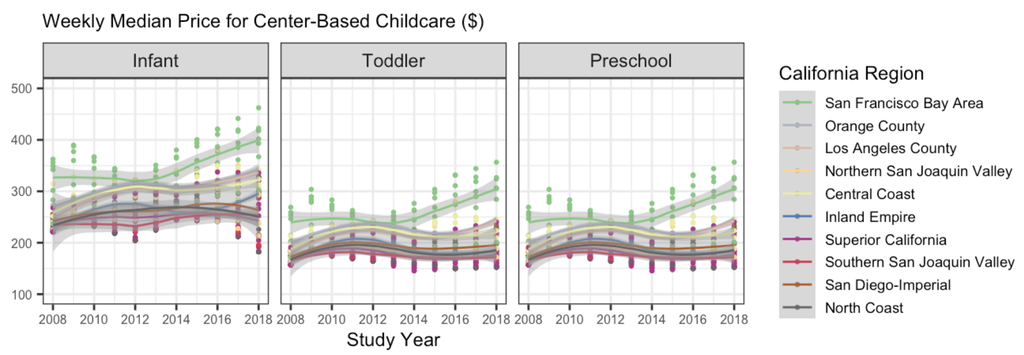

Plot to recreate

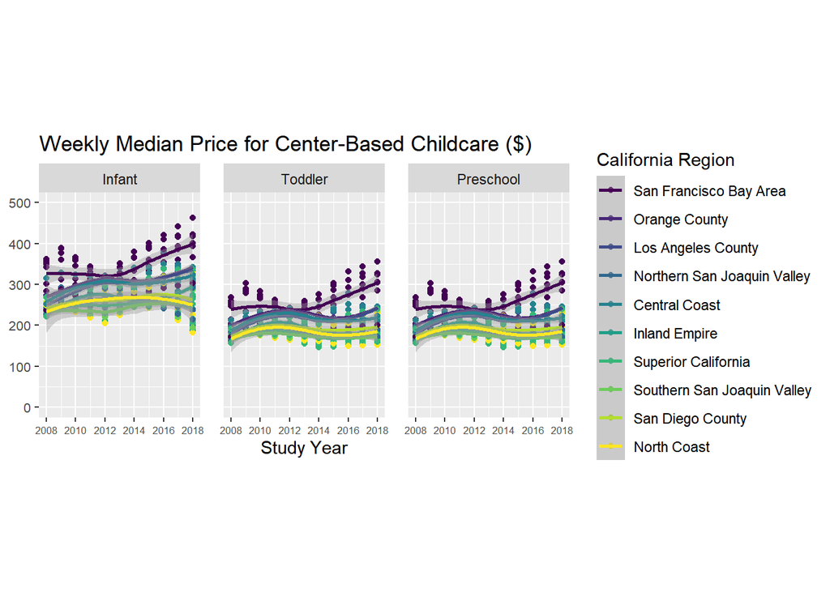

```r
plot_data <- ca_childcare |>
  select(county_name, region, study_year, mc_infant, mc_toddler, mc_preschool) |>
  pivot_longer(cols = c(mc_infant, mc_toddler, mc_preschool),
               names_to = "cc_type",
               values_to = "wkly_med_price"
              ) |>
  mutate(cc_type = fct_recode(cc_type,
      "Infant" = "mc_infant",
      "Toddler" = "mc_toddler",
      "Preschool" = "mc_preschool"))

ggplot(data = plot_data, mapping = aes(x = study_year,
                                       y = wkly_med_price,
                                       color = fct_reorder2(.f = region,
                                                            .x = study_year,
                                                            .y = wkly_med_price)
                                       )
       ) +
  geom_point() +
  geom_smooth(method = 'loess') +
  facet_grid(~ factor(cc_type, levels = c("Infant", "Toddler", "Preschool"))) +
  labs(x = "Study Year",
       y = NULL,
       title = "Weekly Median Price for Center-Based Childcare ($)",
       color = "California Region") +
  scale_y_continuous(limits = c(0,500)) + #http://www.sthda.com/english/wiki/ggplot2-axis-ticks-a-guide-to-customize-tick-marks-and-labels
  scale_x_continuous(breaks = seq.int(2008, 2018, by = 2)) + #https://www.geeksforgeeks.org/get-a-list-of-numbers-in-the-specified-range-in-r-programming-seq-int-function/
  theme(aspect.ratio = 1.4,
        axis.text.x = element_text(size=6),
        axis.text.y = element_text(size=8),#https://stackoverflow.com/questions/14942681/change-size-of-axes-title-and-labels-in-ggplot2
        panel.spacing.x = unit(1, "lines")) + #https://ggplot2.tidyverse.org/reference/theme.html
  scale_colour_viridis_d()
```

## Median Household Income vs. Childcare Costs for Infants

**7. Create a scatterplot showing the relationship between median household income (expressed in 2018 dollars) and the full-time median weekly price charged for center-based childcare for an infant in California. Overlay a linear regression line (lm) to show the trend.**

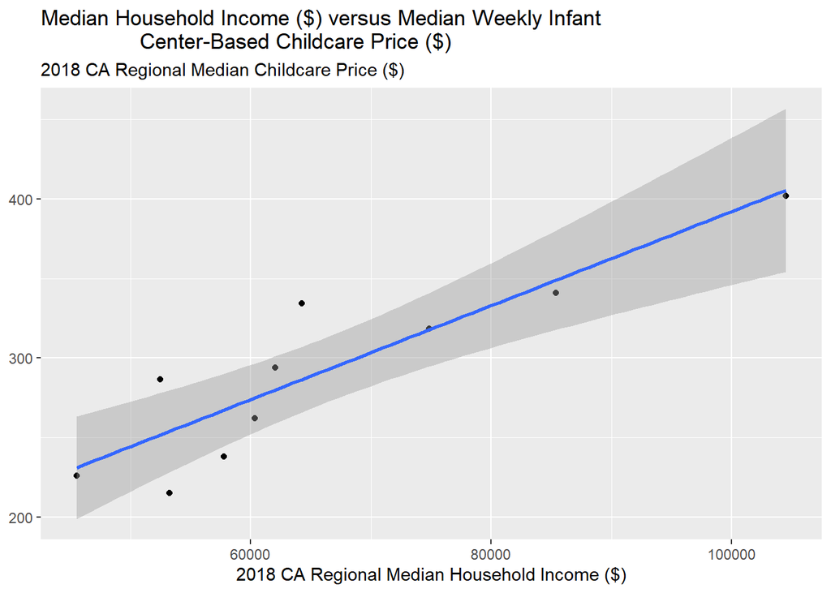

```r
options(scipen = 999) #https://forum.posit.co/t/how-to-turn-off-scientific-notation-like-1e-09-in-r/71575
ggplot(data = income_cc, mapping = aes(y = median_weekly_cc_price,
                                       x = median_household_income)) +
  geom_point() +
  geom_smooth(method = "lm") +
  labs(title = "Median Household Income ($) versus Median Weekly Infant
                Center-Based Childcare Price ($)",
       x = "2018 CA Regional Median Household Income ($)",
       y = NULL,
       subtitle = "2018 CA Regional Median Childcare Price ($)")
```

**8. Look up the documentation for `lm()` and fit a linear regression model to the relationship shown in your plot above.**

```r
# complete the code provided
reg_mod1 <- lm(income_cc$median_weekly_cc_price ~ income_cc$median_household_income)
summary(reg_mod1)
```

```
Call:
lm(formula = income_cc$median_weekly_cc_price ~ income_cc$median_household_income)

Residuals:
   Min     1Q Median     3Q    Max
-38.73 -11.69  -4.41  10.69  47.80

Coefficients:
                                    Estimate Std. Error t value Pr(>|t|)
(Intercept)                       96.4363289 36.0645970   2.674 0.028187 *
income_cc$median_household_income  0.0029566  0.0005292   5.587 0.000518 ***
---
Signif. codes:  0 '***' 0.001 '**' 0.01 '*' 0.05 '.' 0.1 ' ' 1

Residual standard error: 28.12 on 8 degrees of freedom
Multiple R-squared:  0.796, Adjusted R-squared:  0.7705
F-statistic: 31.22 on 1 and 8 DF,  p-value: 0.0005179
```

**9. Using the output from `summary()`, write out the estimated regression line (recall: $y = mx + b$).**

The estimated regression line is: **$y = 0.00296x + 96.4$**

**10. Do you have evidence to conclude there is a relationship between the median household income and the median weekly cost of center-based childcare for infants in California? Cite values from your `summary()` output to support your claim!**

Yes, there is significant evidence to support that there is a significant relationship between median household income and the median weekly cost of center-based childcare for infants in California. With p values of 0.0005 for the slope and 0.0282 for the intercept (both of which are less than alpha = 0.05), we reject the null hypothesis (which states that there is no relationship between median household income and median weekly cost of childcare) and conclude that there is a relationship between median household income and median weekly cost of childcare.